# MV_Coursework_rmd_2060361

#loading the three partitions measurement

```r
#The GDP per capita.
gdp <- UN[,3:14] # The GDP per capita.
years <- seq(1952, 2007,5)
colnames(gdp) <- years
rownames(gdp) <- UN[,2]

#The life expectancy
lifeExp <- UN[,15:26] # the life expectancy
colnames(lifeExp) <- years
rownames(lifeExp) <- UN[,2]


#The population size
popn <- UN[,27:38] # the population size
colnames(popn) <- years
rownames(popn) <- UN[,2]
```

```r
gdp
```

```
##                                1952       1957       1962       1967       1972
## Algeria                   2449.0082  3013.9760  2550.8169  3246.9918  4182.6638
## Angola                    3520.6103  3827.9405  4269.2767  5522.7764  5473.2880
## Benin                     1062.7522   959.6011   949.4991  1035.8314  1085.7969
## Botswana                   851.2411   918.2325   983.6540  1214.7093  2263.6111
## Burkina Faso               543.2552   617.1835   722.5120   794.8266   854.7360
## Burundi                    339.2965   379.5646   355.2032   412.9775   464.0995
## Cameroon                  1172.6677  1313.0481  1399.6074  1508.4531  1684.1465
## Central African Republic  1071.3107  1190.8443  1193.0688  1136.0566  1070.0133
## Chad                      1178.6659  1308.4956  1389.8176  1196.8106  1104.1040
## Comoros                   1102.9909  1211.1485  1406.6483  1876.0296  1937.5777
## Congo Dem. Rep.            780.5423   905.8602   896.3146   861.5932   904.8961
## Congo Rep.                2125.6214  2315.0566  2464.7832  2677.9396  3213.1527
## Cote d'Ivoire             1388.5947  1500.8959  1728.8694  2052.0505  2378.2011
## Djibouti                  2669.5295  2864.9691  3020.9893  3020.0505  3694.2124
## Egypt                     1418.8224  1458.9153  1693.3359  1814.8807  2024.0081
## Equatorial Guinea          375.6431   426.0964   582.8420   915.5960   672.4123
## Eritrea                    328.9406   344.1619   380.9958   468.7950   514.3242
## Ethiopia                   362.1463   378.9042   419.4564   516.1186   566.2439
## Gabon                     4293.4765  4976.1981  6631.4592  8358.7620 11401.9484
## Gambia                     485.2307   520.9267   599.6503   734.7829   756.0868
## Ghana                      911.2989  1043.5615  1190.0411  1125.6972  1178.2237
## Guinea                     510.1965   576.2670   686.3737   708.7595   741.6662
## Guinea-Bissau              299.8503   431.7905   522.0344   715.5806   820.2246
## Kenya                      853.5409   944.4383   896.9664  1056.7365  1222.3600
## Lesotho                    298.8462   335.9971   411.8006   498.6390   496.5816
## Liberia                    575.5730   620.9700   634.1952   713.6036   803.0055
## Libya                     2387.5481  3448.2844  6757.0308 18772.7517 21011.4972
## Madagascar                1443.0117  1589.2027  1643.3871  1634.0473  1748.5630
## Malawi                     369.1651   416.3698   427.9011   495.5148   584.6220
## Mali                       452.3370   490.3822   496.1743   545.0099   581.3689
## Mauritania                 743.1159   846.1203  1055.8960  1421.1452  1586.8518
## Mauritius                 1967.9557  2034.0380  2529.0675  2475.3876  2575.4842
## Morocco                   1688.2036  1642.0023  1566.3535  1711.0448  1930.1950
## Mozambique                 468.5260   495.5868   556.6864   566.6692   724.9178
## Namibia                   2423.7804  2621.4481  3173.2156  3793.6948  3746.0809
## Niger                      761.8794   835.5234   997.7661  1054.3849   954.2092
## Nigeria                   1077.2819  1100.5926  1150.9275  1014.5141  1698.3888
## Reunion                   2718.8853  2769.4518  3173.7233  4021.1757  5047.6586
## Rwanda                     493.3239   540.2894   597.4731   510.9637   590.5807
```

[output cut: 371 more lines]

```
## Netherlands              33724.7578 36797.9333
## Norway                   44683.9753 49357.1902
## Poland                   12002.2391 15389.9247
## Portugal                 19970.9079 20509.6478
## Romania                   7885.3601 10808.4756
## Serbia                    7236.0753  9786.5347
## Slovak Republic          13638.7784 18678.3144
## Slovenia                 20660.0194 25768.2576
## Spain                    24835.4717 28821.0637
## Sweden                   29341.6309 33859.7484
## Switzerland              34480.9577 37506.4191
## Turkey                    6508.0857  8458.2764
## United Kingdom           29478.9992 33203.2613
## Australia                30687.7547 34435.3674
## New Zealand              23189.8014 25185.0091
```

```r
lifeExp
```

```
##                            1952     1957     1962     1967     1972     1977
## Algeria                  43.077 45.68500 48.30300 51.40700 54.51800 58.01400
## Angola                   30.015 31.99900 34.00000 35.98500 37.92800 39.48300
## Benin                    38.223 40.35800 42.61800 44.88500 47.01400 49.19000
## Botswana                 47.622 49.61800 51.52000 53.29800 56.02400 59.31900
## Burkina Faso             31.975 34.90600 37.81400 40.69700 43.59100 46.13700
## Burundi                  39.031 40.53300 42.04500 43.54800 44.05700 45.91000
## Cameroon                 38.523 40.42800 42.64300 44.79900 47.04900 49.35500
## Central African Republic 35.463 37.46400 39.47500 41.47800 43.45700 46.77500
## Chad                     38.092 39.88100 41.71600 43.60100 45.56900 47.38300
## Comoros                  40.715 42.46000 44.46700 46.47200 48.94400 50.93900
## Congo Dem. Rep.          39.143 40.65200 42.12200 44.05600 45.98900 47.80400
## Congo Rep.               42.111 45.05300 48.43500 52.04000 54.90700 55.62500
## Cote d'Ivoire            40.477 42.46900 44.93000 47.35000 49.80100 52.37400
## Djibouti                 34.812 37.32800 39.69300 42.07400 44.36600 46.51900
## Egypt                    41.893 44.44400 46.99200 49.29300 51.13700 53.31900
## Equatorial Guinea        34.482 35.98300 37.48500 38.98700 40.51600 42.02400
## Eritrea                  35.928 38.04700 40.15800 42.18900 44.14200 44.53500
## Ethiopia                 34.078 36.66700 40.05900 42.11500 43.51500 44.51000
## Gabon                    37.003 38.99900 40.48900 44.59800 48.69000 52.79000
## Gambia                   30.000 32.06500 33.89600 35.85700 38.30800 41.84200
## Ghana                    43.149 44.77900 46.45200 48.07200 49.87500 51.75600
## Guinea                   33.609 34.55800 35.75300 37.19700 38.84200 40.76200
## Guinea-Bissau            32.500 33.48900 34.48800 35.49200 36.48600 37.46500
## Kenya                    42.270 44.68600 47.94900 50.65400 53.55900 56.15500
## Lesotho                  42.138 45.04700 47.74700 48.49200 49.76700 52.20800
## Liberia                  38.480 39.48600 40.50200 41.53600 42.61400 43.76400
## Libya                    42.723 45.28900 47.80800 50.22700 52.77300 57.44200
## Madagascar               36.681 38.86500 40.84800 42.88100 44.85100 46.88100
## Malawi                   36.256 37.20700 38.41000 39.48700 41.76600 43.76700
## Mali                     33.685 35.30700 36.93600 38.48700 39.97700 41.71400
## Mauritania               40.543 42.33800 44.24800 46.28900 48.43700 50.85200
## Mauritius                50.986 58.08900 60.24600 61.55700 62.94400 64.93000
## Morocco                  42.873 45.42300 47.92400 50.33500 52.86200 55.73000
## Mozambique               31.286 33.77900 36.16100 38.11300 40.32800 42.49500
## Namibia                  41.725 45.22600 48.38600 51.15900 53.86700 56.43700
## Niger                    37.444 38.59800 39.48700 40.11800 40.54600 41.29100
## Nigeria                  36.324 37.80200 39.36000 41.04000 42.82100 44.51400
## Reunion                  52.724 55.09000 57.66600 60.54200 64.27400 67.06400
## Rwanda                   40.000 41.50000 43.00000 44.10000 44.60000 45.00000
```

[output cut: 229 more lines]

```
## Netherlands              76.050 76.830 77.420 78.030 78.530 79.762
## Norway                   75.970 75.890 77.320 78.320 79.050 80.196
## Poland                   71.320 70.980 70.990 72.750 74.670 75.563
## Portugal                 72.770 74.060 74.860 75.970 77.290 78.098
## Romania                  69.660 69.530 69.360 69.720 71.322 72.476
## Serbia                   70.162 71.218 71.659 72.232 73.213 74.002
## Slovak Republic          70.800 71.080 71.380 72.710 73.800 74.663
## Slovenia                 71.063 72.250 73.640 75.130 76.660 77.926
## Spain                    76.300 76.900 77.570 78.770 79.780 80.941
## Sweden                   76.420 77.190 78.160 79.390 80.040 80.884
## Switzerland              76.210 77.410 78.030 79.370 80.620 81.701
## Turkey                   61.036 63.108 66.146 68.835 70.845 71.777
## United Kingdom           74.040 75.007 76.420 77.218 78.471 79.425
## Australia                74.740 76.320 77.560 78.830 80.370 81.235
## New Zealand              73.840 74.320 76.330 77.550 79.110 80.204
```

```r
popn
```

```
##                               1952      1957      1962      1967      1972
## Algeria                    9279525  10270856  11000948  12760499  14760787
## Angola                     4232095   4561361   4826015   5247469   5894858
## Benin                      1738315   1925173   2151895   2427334   2761407
## Botswana                    442308    474639    512764    553541    619351
## Burkina Faso               4469979   4713416   4919632   5127935   5433886
## Burundi                    2445618   2667518   2961915   3330989   3529983
## Cameroon                   5009067   5359923   5793633   6335506   7021028
## Central African Republic   1291695   1392284   1523478   1733638   1927260
## Chad                       2682462   2894855   3150417   3495967   3899068
## Comoros                     153936    170928    191689    217378    250027
## Congo Dem. Rep.           14100005  15577932  17486434  19941073  23007669
## Congo Rep.                  854885    940458   1047924   1179760   1340458
## Cote d'Ivoire              2977019   3300000   3832408   4744870   6071696
## Djibouti                     63149     71851     89898    127617    178848
## Egypt                     22223309  25009741  28173309  31681188  34807417
## Equatorial Guinea           216964    232922    249220    259864    277603
## Eritrea                    1438760   1542611   1666618   1820319   2260187
## Ethiopia                  20860941  22815614  25145372  27860297  30770372
## Gabon                       420702    434904    455661    489004    537977
## Gambia                      284320    323150    374020    439593    517101
## Ghana                      5581001   6391288   7355248   8490213   9354120
## Guinea                     2664249   2876726   3140003   3451418   3811387
## Guinea-Bissau               580653    601095    627820    601287    625361
## Kenya                      6464046   7454779   8678557  10191512  12044785
## Lesotho                     748747    813338    893143    996380   1116779
## Liberia                     863308    975950   1112796   1279406   1482628
## Libya                      1019729   1201578   1441863   1759224   2183877
## Madagascar                 4762912   5181679   5703324   6334556   7082430
## Malawi                     2917802   3221238   3628608   4147252   4730997
## Mali                       3838168   4241884   4690372   5212416   5828158
## Mauritania                 1022556   1076852   1146757   1230542   1332786
## Mauritius                   516556    609816    701016    789309    851334
## Morocco                    9939217  11406350  13056604  14770296  16660670
## Mozambique                 6446316   7038035   7788944   8680909   9809596
## Namibia                     485831    548080    621392    706640    821782
## Niger                      3379468   3692184   4076008   4534062   5060262
## Nigeria                   33119096  37173340  41871351  47287752  53740085
## Reunion                     257700    308700    358900    414024    461633
## Rwanda                     2534927   2822082   3051242   3451079   3992121
```

[output cut: 371 more lines]

```
## Netherlands                16122830   16570613
## Norway                      4535591    4627926
## Poland                     38625976   38518241
## Portugal                   10433867   10642836
## Romania                    22404337   22276056
## Serbia                     10111559   10150265
## Slovak Republic             5410052    5447502
## Slovenia                    2011497    2009245
## Spain                      40152517   40448191
## Sweden                      8954175    9031088
## Switzerland                 7361757    7554661
## Turkey                     67308928   71158647
## United Kingdom             59912431   60776238
## Australia                  19546792   20434176
## New Zealand                 3908037    4115771
```

##Clustering

```r
UN.scaled <- UN[,1:26]
UN.scaled[,3:26] <- scale(UN[,3:26])
```

```r
UN2 <- UN.scaled[,3:26]
```

#Trying K-means clustering to select number of clusters. # with 2 clusters

```r
set.seed(123)
(UN.k <- kmeans(UN2, centers =2, nstart=25))
```

```
## K-means clustering with 2 clusters of sizes 53, 88
##
## Cluster means:
##   gdpPercap_1952 gdpPercap_1957 gdpPercap_1962 gdpPercap_1967 gdpPercap_1972
## 1      0.8940871      0.9360267      0.9598095      0.9831108      1.0094315
## 2     -0.5384843     -0.5637434     -0.5780671     -0.5921008     -0.6079531
##   gdpPercap_1977 gdpPercap_1982 gdpPercap_1987 gdpPercap_1992 gdpPercap_1997
## 1      0.9840745      1.0255212      1.0418898      1.0164055      1.0133224
## 2     -0.5926812     -0.6176435     -0.6275018     -0.6121533     -0.6102964
##   gdpPercap_2002 gdpPercap_2007 lifeExp_1952 lifeExp_1957 lifeExp_1962
## 1      1.0130770      1.0352690    1.0519724    1.0476991    1.0435420
## 2     -0.6101486     -0.6235143   -0.6335743   -0.6310006   -0.6284969
##   lifeExp_1967 lifeExp_1972 lifeExp_1977 lifeExp_1982 lifeExp_1987 lifeExp_1992
## 1    1.0304655    1.0150943    0.9980836    0.9876559    0.9598779    0.9093282
## 2   -0.6206212   -0.6113636   -0.6011185   -0.5948382   -0.5781083   -0.5476636
##   lifeExp_1997 lifeExp_2002 lifeExp_2007
## 1    0.9106691    0.8963674    0.8835193
## 2   -0.5484711   -0.5398577   -0.5321196
##
## Clustering vector:
##   [1] 2 2 2 2 2 2 2 2 2 2 2 2 2 2 2 2 2 2 2 2 2 2 2 2 2 2 1 2 2 2 2 2 2 2 2 2 2
##  [38] 2 2 2 2 2 2 2 2 2 2 2 2 2 2 2 1 2 2 1 1 2 1 1 2 2 2 2 2 2 1 1 2 1 2 2 1 1
##  [75] 1 1 1 2 1 2 2 2 1 2 2 2 2 1 1 2 2 1 1 2 2 2 2 1 2 2 1 1 2 2 1 2 2 2 2 2 1
## [112] 1 2 1 1 1 1 1 1 1 1 1 1 1 1 1 1 1 1 1 1 1 1 1 1 1 1 2 1 1 1
##
## Within cluster sum of squares by cluster:
## [1] 674.3781 701.4790
##  (between_SS / total_SS =  59.1 %)
##
## Available components:
##
## [1] "cluster"      "centers"      "totss"        "withinss"     "tot.withinss"
## [6] "betweenss"    "size"         "iter"         "ifault"
```

```r
#install.packages("factoextra")
library(factoextra)
```

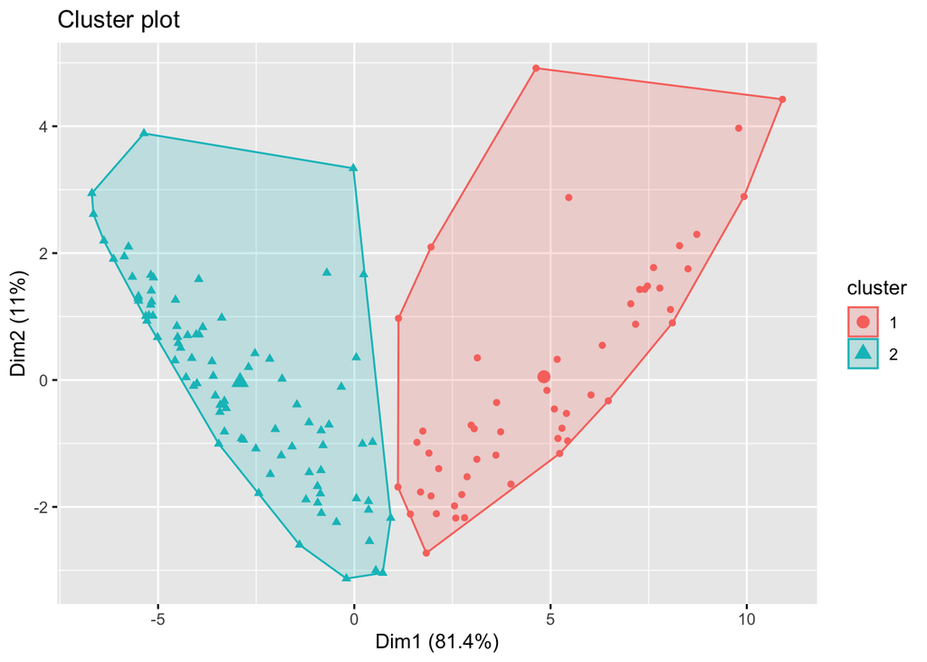

```r
fviz_cluster(UN.k, data = UN2, geom = "point" )
```

#Figure 8. Cluster plot with 2 clusters centers.

```r
set.seed(123)
(UN.k <- kmeans(UN2, centers =3, nstart=25))
```

```
## K-means clustering with 3 clusters of sizes 59, 54, 28
##
## Cluster means:
##   gdpPercap_1952 gdpPercap_1957 gdpPercap_1962 gdpPercap_1967 gdpPercap_1972
## 1    -0.08712804    -0.07653668     -0.0909903    -0.06879877    -0.07166286
## 2    -0.68496313    -0.71188702     -0.7284738    -0.73865624    -0.75875386
## 3     1.50459153     1.53419868      1.5966432     1.56952016     1.61431491
##   gdpPercap_1977 gdpPercap_1982 gdpPercap_1987 gdpPercap_1992 gdpPercap_1997
## 1    -0.03854141     -0.0740099     -0.1092369     -0.1546081     -0.1478367
## 2    -0.77760811     -0.7880114     -0.7795864     -0.7485823     -0.7503789
## 3     1.58088504      1.6756858      1.7336658      1.7694758      1.7586723
##   gdpPercap_2002 gdpPercap_2007 lifeExp_1952 lifeExp_1957 lifeExp_1962
## 1     -0.1689013     -0.1454416    0.1861849    0.2478387    0.2815571
## 2     -0.7348545     -0.7509692   -0.9211459   -0.9543387   -0.9699375
## 3      1.7731186      1.7547640    1.3841774    1.3182789    1.2773128
##   lifeExp_1967 lifeExp_1972 lifeExp_1977 lifeExp_1982 lifeExp_1987 lifeExp_1992
## 1    0.3284615    0.3783877    0.4067163     0.425688    0.4595034     0.469467
## 2   -1.0034876   -1.0336543   -1.0516338    -1.068469   -1.0893169    -1.075997
## 3    1.2431821    1.1961592    1.1711416     1.163633    1.1325861     1.085903
##   lifeExp_1997 lifeExp_2002 lifeExp_2007
## 1    0.4963545    0.4963762    0.4805148
## 2   -1.1035908   -1.0913421   -1.0693034
## 3    1.0824639    1.0587955    1.0497146
##
## Clustering vector:
##   [1] 1 2 2 2 2 2 2 2 2 2 2 2 2 2 1 2 2 2 1 2 2 2 2 2 2 2 1 2 2 2 2 1 1 2 2 2 2
##  [38] 1 2 1 2 2 2 1 2 2 2 2 1 2 2 2 1 2 1 3 1 1 1 1 1 1 1 1 2 1 1 1 1 1 1 1 1 1
##  [75] 3 1 1 2 3 2 2 1 3 2 2 1 1 3 3 1 1 1 1 1 2 2 2 1 2 1 3 3 1 1 1 1 1 1 2 1 3
## [112] 3 1 1 1 3 3 3 3 3 3 1 3 3 3 1 3 3 1 1 1 1 1 3 3 3 3 1 3 3 3
##
## Within cluster sum of squares by cluster:
## [1] 368.2523 195.4098 219.5828
##  (between_SS / total_SS =  76.7 %)
##
## Available components:
##
## [1] "cluster"      "centers"      "totss"        "withinss"     "tot.withinss"
## [6] "betweenss"    "size"         "iter"         "ifault"
```

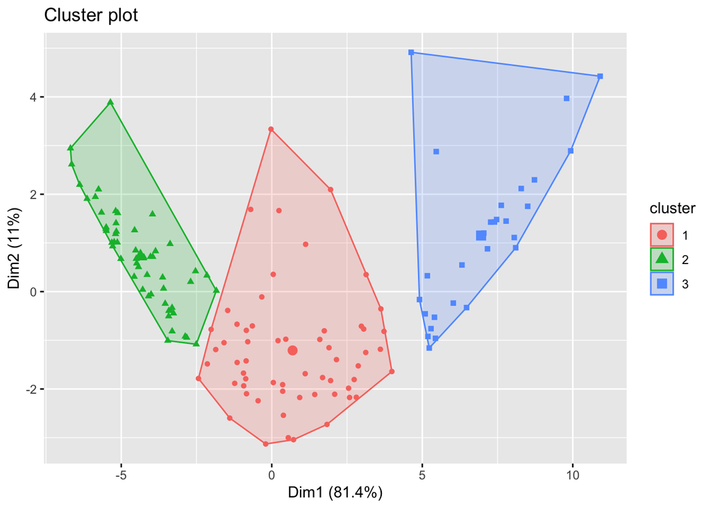

```r
fviz_cluster(UN.k, data = UN2, geom = "point" )
```

#Figure 9. Cluster plot with 3 clusters centers.

```r
set.seed(123)
(UN.k <- kmeans(UN2, centers =5, nstart=25))
```

```
## K-means clustering with 5 clusters of sizes 32, 38, 39, 15, 17
##
## Cluster means:
##   gdpPercap_1952 gdpPercap_1957 gdpPercap_1962 gdpPercap_1967 gdpPercap_1972
## 1   -0.009091373     0.01801624    -0.01487531     0.03224469     0.04239621
## 2   -0.414756159    -0.43884528    -0.45289290    -0.46306071    -0.48271058
## 3   -0.708222646    -0.73047584    -0.74681841    -0.75961275    -0.78109242
## 4    0.439057495     0.49658122     0.64419530     0.69371474     0.83347670
## 5    2.181557574     2.18467297     2.18523109     2.10492076     2.05569278
##   gdpPercap_1977 gdpPercap_1982 gdpPercap_1987 gdpPercap_1992 gdpPercap_1997
## 1     0.04370092     0.03570817    0.008701377    -0.05221904    -0.04711175
## 2    -0.43419794    -0.48201991   -0.513446058    -0.51058548    -0.51108446
## 3    -0.80078025    -0.81942760   -0.812388245    -0.78559576    -0.78583235
## 4     0.83262410     0.98164648    1.093277365     1.14440614     1.23331751
## 5     1.99071532     2.02394554    2.030381601     2.03208233     1.94567556
##   gdpPercap_2002 gdpPercap_2007 lifeExp_1952 lifeExp_1957 lifeExp_1962
## 1    -0.07609098    -0.01844406    0.4951433    0.5750429    0.6224480
## 2    -0.52277940    -0.53868530   -0.5151007   -0.4868466   -0.4647293
## 3    -0.76736137    -0.78279939   -1.0162239   -1.0653400   -1.0977199
## 4     1.29728342     1.36327288    1.2495264    1.2442483    1.2479041
## 5     1.92755122     1.83178437    1.4481810    1.3519606    1.2843467
##   lifeExp_1967 lifeExp_1972 lifeExp_1977 lifeExp_1982 lifeExp_1987 lifeExp_1992
## 1    0.6413657    0.6773239    0.6877891    0.6982681    0.6853680   0.64939180
## 2   -0.3956246   -0.3256344   -0.2600889   -0.2212105   -0.1387904  -0.05100579
## 3   -1.1550474   -1.2125625   -1.2572693   -1.2900295   -1.3296998  -1.33809953
## 4    1.2386434    1.1957877    1.1412121    1.1117021    1.0699400   0.99161494
## 5    1.2339547    1.1795800    1.1640852    1.1586492    1.1265560   1.08643175
##   lifeExp_1997 lifeExp_2002 lifeExp_2007
## 1   0.65317100   0.64669708    0.6304496
## 2  -0.04396184  -0.06178858   -0.0504623
## 3  -1.34763861  -1.31195975   -1.3005281
## 4   1.00656523   1.00804909    0.9929680
## 5   1.07226501   1.04113844    1.0334855
##
## Clustering vector:
##   [1] 2 3 3 2 3 3 3 3 3 2 3 2 3 3 2 3 3 3 2 3 2 3 3 2 3 3 1 3 3 3 2 1 2 3 2 3 3
##  [38] 1 3 2 2 3 3 2 3 3 3 2 2 3 3 3 1 2 1 5 1 1 1 1 2 1 2 2 3 2 1 1 2 1 1 2 4 1
##  [75] 5 1 1 3 5 3 3 2 4 2 2 2 2 4 4 2 1 1 1 1 2 2 3 1 2 2 5 4 1 2 1 2 2 2 3 1 5
## [112] 5 1 1 1 4 5 4 5 5 4 4 5 4 4 1 5 5 1 4 1 1 4 4 4 5 5 2 5 5 5
##
## Within cluster sum of squares by cluster:
## [1] 140.76172 134.78017 105.95190  45.37676  96.89857
##  (between_SS / total_SS =  84.4 %)
##
## Available components:
##
## [1] "cluster"      "centers"      "totss"        "withinss"     "tot.withinss"
## [6] "betweenss"    "size"         "iter"         "ifault"
```

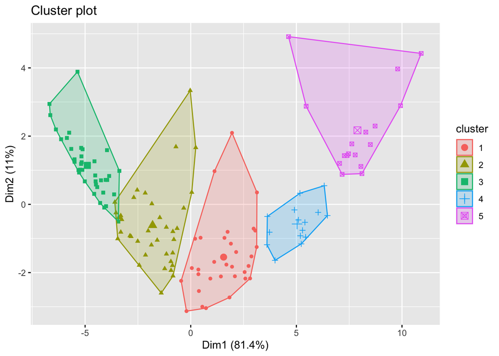

```r
fviz_cluster(UN.k, data = UN2, geom = "point" )
```

#Figure 10. Cluster plot with 5 clusters centers.

# Elbow method to get the optimalnumber of clusters

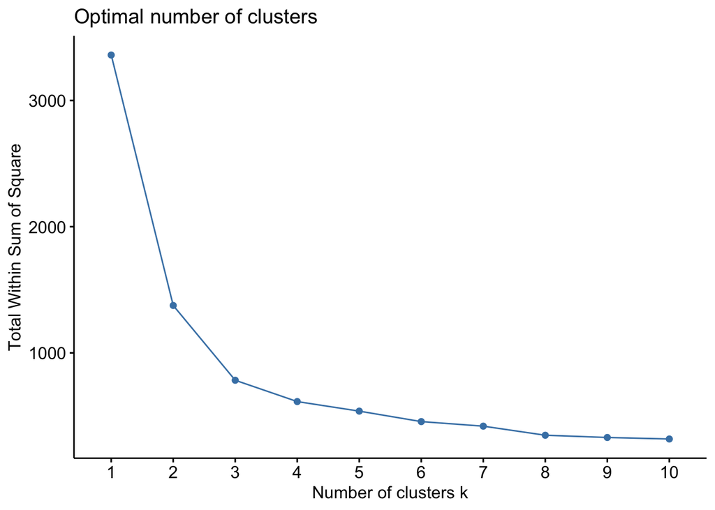

```r
fviz_nbclust(UN2, kmeans, method = "wss")
```

#Figure 11. Elbow plot to determine optimal number of clusters.

# Trying the hierarchical based clustering

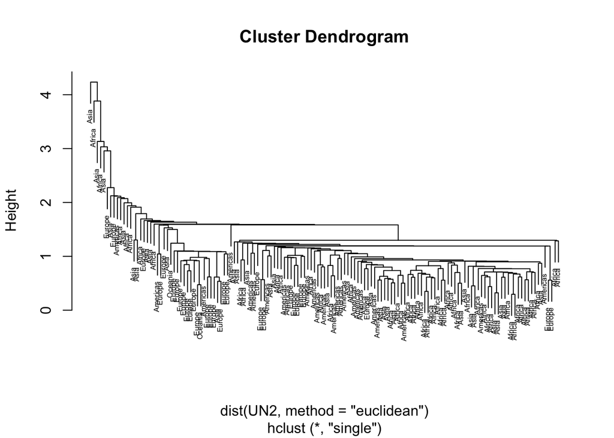

```r
UN.sl <-hclust(dist(UN2, method ="euclidean"), method="single")
plot(UN.sl, labels = UN$continent, cex=0.5)
```

#Figure 12. Single linkage method.

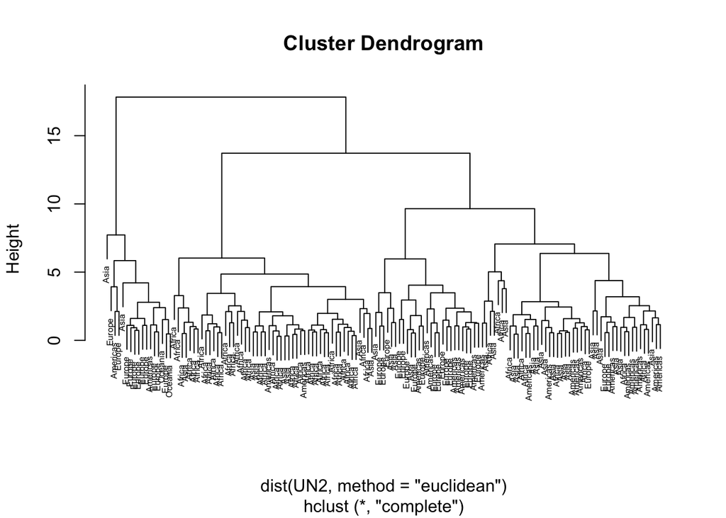

```r
UN.comp <-hclust(dist(UN2, method ="euclidean"), method="complete")

plot(UN.comp, labels = UN$continent, cex=0.5)
```

#Figure 13. complete linkage method.

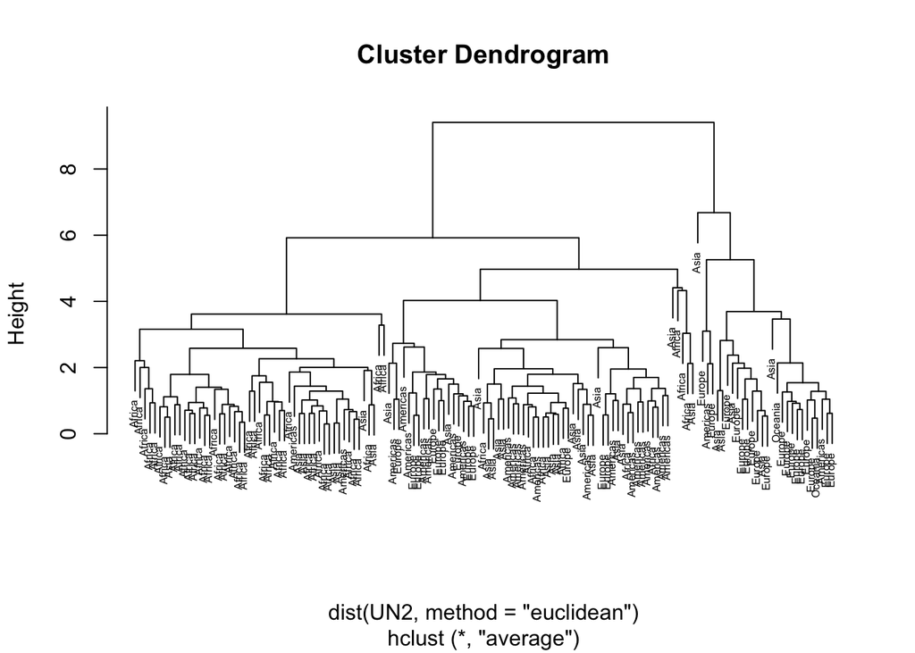

```r
UN.av <-hclust(dist(UN2, method ="euclidean"), method="average")

plot(UN.av, labels = UN$continent, cex=0.5)
```

#Figure 14. average linkage method

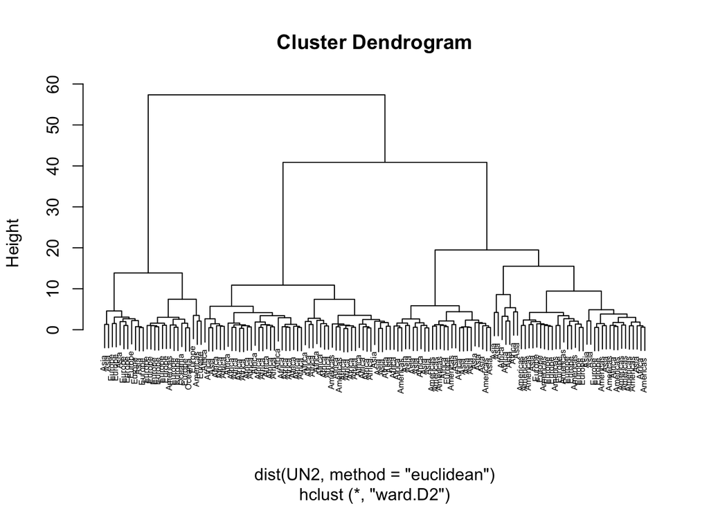

```r
UN.ward <-hclust(dist(UN2, method ="euclidean"), method="ward.D2")

plot(UN.ward, labels = UN$continent, cex=0.5)
```

#Figure 15. Ward linkage method.

#Based on observation Figure 13. the complete and Figure 15. ward linkage dendrograms appears to be very close, but single and average linkage method is completely different. #To see that the complete and ward linkage dendrograms are similar, they will be used to create 3clusters to observe the simmilarities.

```r
table(cutree(UN.comp, k=3), cutree(UN.ward, k=3))
```

```
##
##      1  2  3
##   1 62  0 11
##   2  2 49  0
##   3  2  0 15
```

#Linear Discriminant Analysis.

```r
head(UN)
```

```
##   continent      country gdpPercap_1952 gdpPercap_1957 gdpPercap_1962
## 1    Africa      Algeria      2449.0082      3013.9760      2550.8169
## 2    Africa       Angola      3520.6103      3827.9405      4269.2767
## 3    Africa        Benin      1062.7522       959.6011       949.4991
## 4    Africa     Botswana       851.2411       918.2325       983.6540
## 5    Africa Burkina Faso       543.2552       617.1835       722.5120
## 6    Africa      Burundi       339.2965       379.5646       355.2032
##   gdpPercap_1967 gdpPercap_1972 gdpPercap_1977 gdpPercap_1982 gdpPercap_1987
## 1      3246.9918      4182.6638      4910.4168      5745.1602      5681.3585
## 2      5522.7764      5473.2880      3008.6474      2756.9537      2430.2083
## 3      1035.8314      1085.7969      1029.1613      1277.8976      1225.8560
## 4      1214.7093      2263.6111      3214.8578      4551.1421      6205.8839
## 5       794.8266       854.7360       743.3870       807.1986       912.0631
## 6       412.9775       464.0995       556.1033       559.6032       621.8188
##   gdpPercap_1992 gdpPercap_1997 gdpPercap_2002 gdpPercap_2007 lifeExp_1952
```

[output cut: 34 more lines]

#Transforming the data to the long format consisting of the continents for each country and the average life expectancy, population and gdp per capita over 55 years to predict the continents

```r
pop_long <- UN %>%
  gather(key = "year_pop", value = "pop", starts_with("pop_")) %>%
  mutate(year = as.integer(substr(year_pop, 5, 8))) %>% # Extracting the year from column names
  select(-year_pop)
```

```r
UN_long <- gdp_long %>%
  left_join(lifeExp_long, by = c("continent", "country", "year")) %>%
  left_join(pop_long, by = c("continent", "country", "year"))
UN_long
```

```
## # A tibble: 1,692 × 78
##    continent country lifeExp_1952.x lifeExp_1957.x lifeExp_1962.x lifeExp_1967.x
##    <chr>     <chr>            <dbl>          <dbl>          <dbl>          <dbl>
##  1 Africa    Algeria           43.1           45.7           48.3           51.4
##  2 Africa    Algeria           43.1           45.7           48.3           51.4
##  3 Africa    Algeria           43.1           45.7           48.3           51.4
##  4 Africa    Algeria           43.1           45.7           48.3           51.4
##  5 Africa    Algeria           43.1           45.7           48.3           51.4
##  6 Africa    Algeria           43.1           45.7           48.3           51.4
##  7 Africa    Algeria           43.1           45.7           48.3           51.4
##  8 Africa    Algeria           43.1           45.7           48.3           51.4
##  9 Africa    Algeria           43.1           45.7           48.3           51.4
## 10 Africa    Algeria           43.1           45.7           48.3           51.4
## # ℹ 1,682 more rows
## # ℹ 72 more variables: lifeExp_1972.x <dbl>, lifeExp_1977.x <dbl>,
## #   lifeExp_1982.x <dbl>, lifeExp_1987.x <dbl>, lifeExp_1992.x <dbl>,
## #   lifeExp_1997.x <dbl>, lifeExp_2002.x <dbl>, lifeExp_2007.x <dbl>,
## #   pop_1952.x <dbl>, pop_1957.x <dbl>, pop_1962.x <dbl>, pop_1967.x <dbl>,
## #   pop_1972.x <dbl>, pop_1977.x <dbl>, pop_1982.x <dbl>, pop_1987.x <dbl>,
## #   pop_1992.x <dbl>, pop_1997.x <dbl>, pop_2002.x <int>, pop_2007.x <int>, …
```

```r
UN_avg <- UN_long %>%
  group_by(continent, country) %>%
  summarise(avg_gdpPercap = mean(gdpPercap, na.rm = TRUE),
            avg_lifeExp = mean(lifeExp, na.rm = TRUE), avg_pop_= mean(pop, na.rm = TRUE))
UN_avg
```

```
## # A tibble: 141 × 5
## # Groups:   continent [5]
##    continent country                  avg_gdpPercap avg_lifeExp  avg_pop_
##    <chr>     <chr>                            <dbl>       <dbl>     <dbl>
##  1 Africa    Algeria                          4426.        59.0 19875406.
##  2 Africa    Angola                           3607.        37.9  7309390.
##  3 Africa    Benin                            1155.        48.8  4017497.
##  4 Africa    Botswana                         5032.        54.6   971186.
##  5 Africa    Burkina Faso                      844.        44.7  7548677.
##  6 Africa    Burundi                           472.        44.8  4651608.
##  7 Africa    Cameroon                         1775.        48.1  9816648.
##  8 Africa    Central African Republic          959.        43.9  2560963
##  9 Africa    Chad                             1165.        46.8  5329256.
## 10 Africa    Comoros                          1314.        52.4   361684.
## # ℹ 131 more rows
```

#Using caret package to randomly split dataset into traina and test

```r
#install.packages("caret")
library(caret)
#install.packages("MASS")
library(MASS)
```

```r
set.seed(123)

partition = createDataPartition(UN_avg$continent, p=0.7, list = FALSE)

UN_avg.test <-UN_avg[partition,]
UN_avg.train <- UN_avg[-partition,]
```

#Using linear discriminant analysis to train a classifier to predict the continent of each country.

```r
UN_lda = lda(continent ~ avg_gdpPercap + avg_lifeExp + avg_pop_, data =UN_avg.train)
```

```r
UN_avg.predict <-predict(UN_lda, UN_avg.test)
```

#Test the accuracy of your model

```r
accuracy = mean(UN_avg.predict$class == UN_avg.test$continent) *100
print(paste("The predictive accuracy is :", round(accuracy, 2),"%" )) #calculating the predictive accuracy on the test set
```

```
## [1] "The predictive accuracy is : 61.39 %"
```

#The predictive accuracy appears to be fairly above average at 61.39 % using the average life expectancy, population and gdp per capita over 55 years to predict the continents. # Attempting to use all the years of the life expectancy, population and gdp per capita to train the classifier and compare results.

```r
table(UN_avg.predict$class, UN_avg.test$continent)
```

```
##
##            Africa Americas Asia Europe Oceania
##   Africa       32        3    5      0       0
##   Americas      0        3    6      0       0
##   Asia          3        3    6      0       0
##   Europe        2        9    6     21       2
```

```r
head(UN)
```

```
##   continent      country gdpPercap_1952 gdpPercap_1957 gdpPercap_1962
## 1    Africa      Algeria      2449.0082      3013.9760      2550.8169
## 2    Africa       Angola      3520.6103      3827.9405      4269.2767
## 3    Africa        Benin      1062.7522       959.6011       949.4991
## 4    Africa     Botswana       851.2411       918.2325       983.6540
## 5    Africa Burkina Faso       543.2552       617.1835       722.5120
## 6    Africa      Burundi       339.2965       379.5646       355.2032
##   gdpPercap_1967 gdpPercap_1972 gdpPercap_1977 gdpPercap_1982 gdpPercap_1987
## 1      3246.9918      4182.6638      4910.4168      5745.1602      5681.3585
## 2      5522.7764      5473.2880      3008.6474      2756.9537      2430.2083
## 3      1035.8314      1085.7969      1029.1613      1277.8976      1225.8560
## 4      1214.7093      2263.6111      3214.8578      4551.1421      6205.8839
## 5       794.8266       854.7360       743.3870       807.1986       912.0631
## 6       412.9775       464.0995       556.1033       559.6032       621.8188
##   gdpPercap_1992 gdpPercap_1997 gdpPercap_2002 gdpPercap_2007 lifeExp_1952
```

[output cut: 34 more lines]

```r
#splitting data set into  training and test set of ratio 70:30
library(caret)
set.seed(123)

partition2 = createDataPartition(UN$continent, p=0.7, list = FALSE)

UN_all.test <-UN[partition2,]
UN_all.train <- UN[-partition2,]


#Using linear discriminant analysis to train a classifier to predict the continent of each country.

predictors <- names(UN_all.train)[3:26]
formula_str <- paste("continent ~", paste(predictors, collapse = " + "))
lda_formula <- as.formula(formula_str)

#Using this formula in lda
UN_lda2 <- lda(formula = lda_formula, data = UN_all.train)
UN_all.predict <-predict(UN_lda2, UN_all.test)


#Test the accuracy of your model

accuracy = mean(UN_all.predict$class == UN_all.test$continent) *100
print(paste("The predictive accuracy is :", round(accuracy, 2),"%" )) #calculating the predictive accuracy on the test set
```

```
## [1] "The predictive accuracy is : 51.49 %"
```

#The predictive accuracy 51.49 % appears to have dropped using all the life expectancy, population and gdp per capita over 55 years as compared to the previous training with an accuracy of 61.39 %. So we adopt the first model variables.

1. #Linear regression

```r
#install.packages("pls")
library(pls)
head(gdp)
```

```
##                   1952      1957      1962      1967      1972      1977
## Algeria      2449.0082 3013.9760 2550.8169 3246.9918 4182.6638 4910.4168
## Angola       3520.6103 3827.9405 4269.2767 5522.7764 5473.2880 3008.6474
## Benin        1062.7522  959.6011  949.4991 1035.8314 1085.7969 1029.1613
## Botswana      851.2411  918.2325  983.6540 1214.7093 2263.6111 3214.8578
## Burkina Faso  543.2552  617.1835  722.5120  794.8266  854.7360  743.3870
## Burundi       339.2965  379.5646  355.2032  412.9775  464.0995  556.1033
##                   1982      1987      1992      1997       2002       2007
## Algeria      5745.1602 5681.3585 5023.2166 4797.2951  5288.0404  6223.3675
## Angola       2756.9537 2430.2083 2627.8457 2277.1409  2773.2873  4797.2313
## Benin        1277.8976 1225.8560 1191.2077 1232.9753  1372.8779  1441.2849
## Botswana     4551.1421 6205.8839 7954.1116 8647.1423 11003.6051 12569.8518
## Burkina Faso  807.1986  912.0631  931.7528  946.2950  1037.6452  1217.0330
## Burundi       559.6032  621.8188  631.6999  463.1151   446.4035   430.0707
```

```r
head(lifeExp)
```

```
##                1952   1957   1962   1967   1972   1977   1982   1987   1992
## Algeria      43.077 45.685 48.303 51.407 54.518 58.014 61.368 65.799 67.744
## Angola       30.015 31.999 34.000 35.985 37.928 39.483 39.942 39.906 40.647
## Benin        38.223 40.358 42.618 44.885 47.014 49.190 50.904 52.337 53.919
## Botswana     47.622 49.618 51.520 53.298 56.024 59.319 61.484 63.622 62.745
## Burkina Faso 31.975 34.906 37.814 40.697 43.591 46.137 48.122 49.557 50.260
## Burundi      39.031 40.533 42.045 43.548 44.057 45.910 47.471 48.211 44.736
##                1997   2002   2007
## Algeria      69.152 70.994 72.301
## Angola       40.963 41.003 42.731
## Benin        54.777 54.406 56.728
## Botswana     52.556 46.634 50.728
## Burkina Faso 50.324 50.650 52.295
## Burundi      45.326 47.360 49.580
```

```r
lifeExp_2007= lifeExp[,12]
lifeExp_2007 = data.frame(lifeExp_2007)

combined_UN = cbind.data.frame(lifeExp_2007, gdp)
combined_UN
```

```
##                          lifeExp_2007       1952       1957       1962
## Algeria                        72.301  2449.0082  3013.9760  2550.8169
## Angola                         42.731  3520.6103  3827.9405  4269.2767
## Benin                          56.728  1062.7522   959.6011   949.4991
## Botswana                       50.728   851.2411   918.2325   983.6540
## Burkina Faso                   52.295   543.2552   617.1835   722.5120
## Burundi                        49.580   339.2965   379.5646   355.2032
## Cameroon                       50.430  1172.6677  1313.0481  1399.6074
## Central African Republic       44.741  1071.3107  1190.8443  1193.0688
## Chad                           50.651  1178.6659  1308.4956  1389.8176
## Comoros                        65.152  1102.9909  1211.1485  1406.6483
## Congo Dem. Rep.                46.462   780.5423   905.8602   896.3146
## Congo Rep.                     55.322  2125.6214  2315.0566  2464.7832
## Cote d'Ivoire                  48.328  1388.5947  1500.8959  1728.8694
## Djibouti                       54.791  2669.5295  2864.9691  3020.9893
## Egypt                          71.338  1418.8224  1458.9153  1693.3359
## Equatorial Guinea              51.579   375.6431   426.0964   582.8420
## Eritrea                        58.040   328.9406   344.1619   380.9958
## Ethiopia                       52.947   362.1463   378.9042   419.4564
## Gabon                          56.735  4293.4765  4976.1981  6631.4592
## Gambia                         59.448   485.2307   520.9267   599.6503
## Ghana                          60.022   911.2989  1043.5615  1190.0411
## Guinea                         56.007   510.1965   576.2670   686.3737
## Guinea-Bissau                  46.388   299.8503   431.7905   522.0344
## Kenya                          54.110   853.5409   944.4383   896.9664
## Lesotho                        42.592   298.8462   335.9971   411.8006
## Liberia                        45.678   575.5730   620.9700   634.1952
## Libya                          73.952  2387.5481  3448.2844  6757.0308
## Madagascar                     59.443  1443.0117  1589.2027  1643.3871
## Malawi                         48.303   369.1651   416.3698   427.9011
## Mali                           54.467   452.3370   490.3822   496.1743
## Mauritania                     64.164   743.1159   846.1203  1055.8960
## Mauritius                      72.801  1967.9557  2034.0380  2529.0675
## Morocco                        71.164  1688.2036  1642.0023  1566.3535
## Mozambique                     42.082   468.5260   495.5868   556.6864
## Namibia                        52.906  2423.7804  2621.4481  3173.2156
## Niger                          56.867   761.8794   835.5234   997.7661
## Nigeria                        46.859  1077.2819  1100.5926  1150.9275
## Reunion                        76.442  2718.8853  2769.4518  3173.7233
## Rwanda                         46.242   493.3239   540.2894   597.4731
```

[output cut: 371 more lines]

```
## Netherlands              26790.9496 30246.1306 33724.7578 36797.9333
## Norway                   33965.6611 41283.1643 44683.9753 49357.1902
## Poland                    7738.8812 10159.5837 12002.2391 15389.9247
## Portugal                 16207.2666 17641.0316 19970.9079 20509.6478
## Romania                   6598.4099  7346.5476  7885.3601 10808.4756
## Serbia                    9325.0682  7914.3203  7236.0753  9786.5347
## Slovak Republic           9498.4677 12126.2306 13638.7784 18678.3144
## Slovenia                 14214.7168 17161.1073 20660.0194 25768.2576
## Spain                    18603.0645 20445.2990 24835.4717 28821.0637
## Sweden                   23880.0168 25266.5950 29341.6309 33859.7484
## Switzerland              31871.5303 32135.3230 34480.9577 37506.4191
## Turkey                    5678.3483  6601.4299  6508.0857  8458.2764
## United Kingdom           22705.0925 26074.5314 29478.9992 33203.2613
## Australia                23424.7668 26997.9366 30687.7547 34435.3674
## New Zealand              18363.3249 21050.4138 23189.8014 25185.0091
```

```r
dim(combined_UN)
```

```
## [1] 141  13
```

```r
# Renaming year columns to start with 'gdp_' prefix
colnames(combined_UN)[2:13] <- paste("gdp", names(combined_UN)[2:13], sep = "_")
```

```r
predictors = names(combined_UN)[2:13]
formula_str = paste("lifeExp_2007~", paste(predictors, collapse = " + "))
lm_formula = as.formula(formula_str)

#Using this formula in lm
combined_UN_lm <- lm(formula = lm_formula, data = combined_UN )
```

```r
coef(combined_UN_lm)[1:100]
```

[output not shown]

```r
sum(!is.na(coef(combined_UN_lm)))
```

```
## [1] 13
```

```r
#install.packages("tinytex")
#tinytex::install_tinytex()
```

```r
tinytex:::is_tinytex()
```

```
## [1] TRUE
```

```r
#tinytex::install_tinytex()
```

```r
tinytex:::is_tinytex()
```

```
## [1] TRUE
```